# day1

### 图形属性映射

> 图片的最大价值在于促使我们发现从未预料到的事情。 ——John Tukey

**向二维散点图添加第三个变量**: *class*，方式是将它映射为**图形属性**，如数据点的大小、形状、颜色。

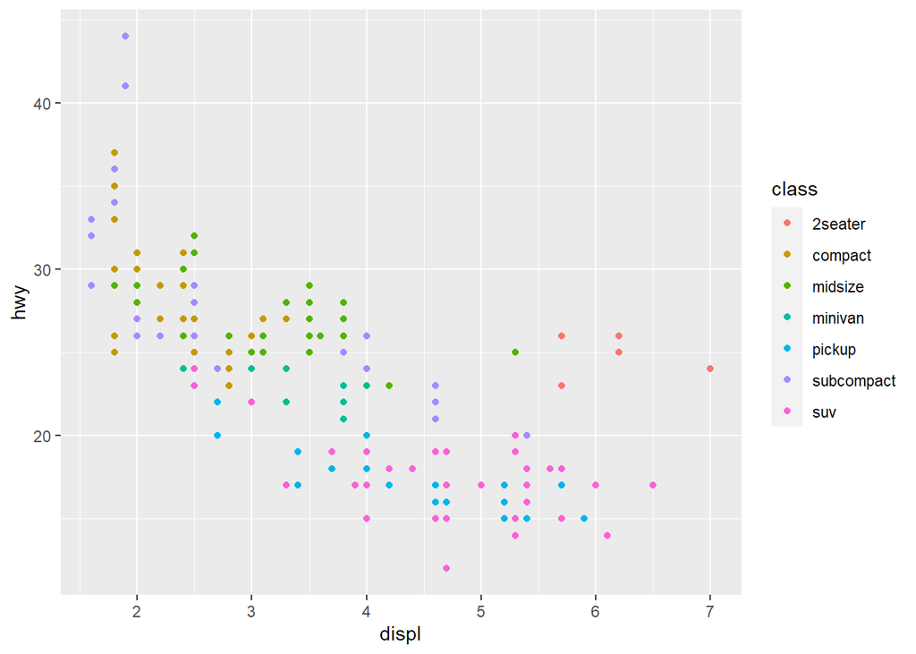

```r
ggplot(data=mpg)+geom_point(mapping=aes(x = displ, y = hwy, color =class))
```

要是用图形属性，就要在函数aes()中将属性与变量名称关联，称为**标度变换**

若将class映射为大小，会收到警告：无序变量(class)(<char>)映射到有序图形属性(size<float>)

```
## Warning: Using size for a discrete variable is not advised.
```

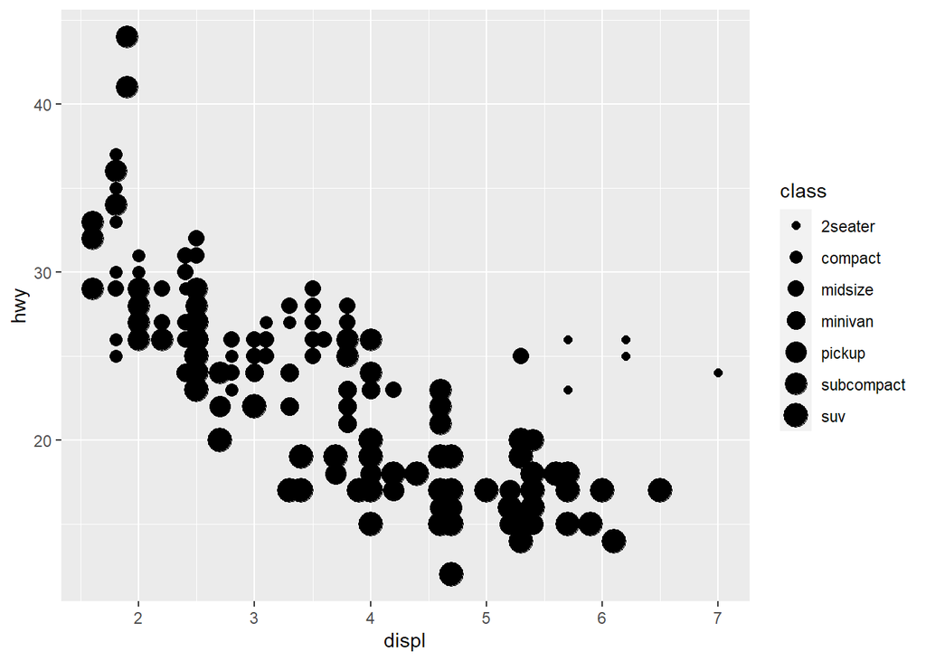

```
#> Warning: Using size for a discrete variable is not advised
```

```r
ggplot(data = mpg) +
 geom_point(mapping = aes(x = displ, y = hwy, size = class))
```

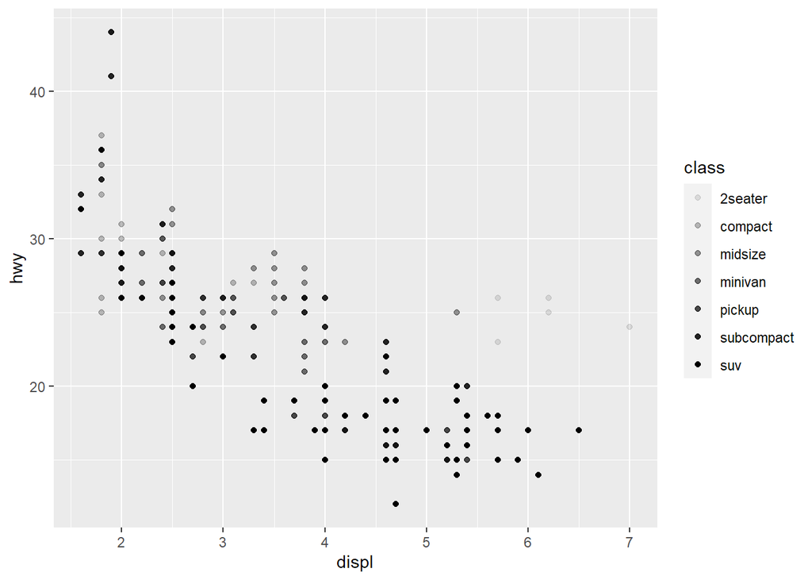

```r
ggplot(data = mpg) +
 geom_point(mapping = aes(x = displ, y = hwy, alpha = class))
```

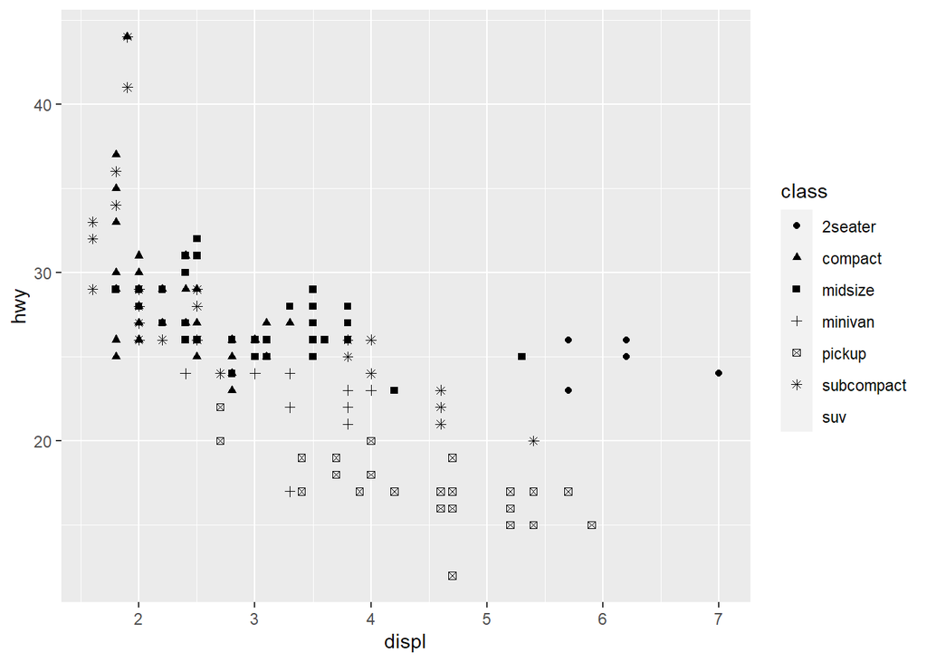

```r
ggplot(data = mpg) +
 geom_point(mapping = aes(x = displ, y = hwy, shape = class))
```

- **Attention**
- ggplot2 只能同时使用 6 种形状，多出的变量值将不会出现在图中。

+ggplot2 不会为 x 和y这两个图形属性创建图例，而会创建带有刻度标记和标签的坐标轴。坐标轴就相当于图例，可以体现出位置和变量值之间的映射关系。

##### 手动设置图形属性

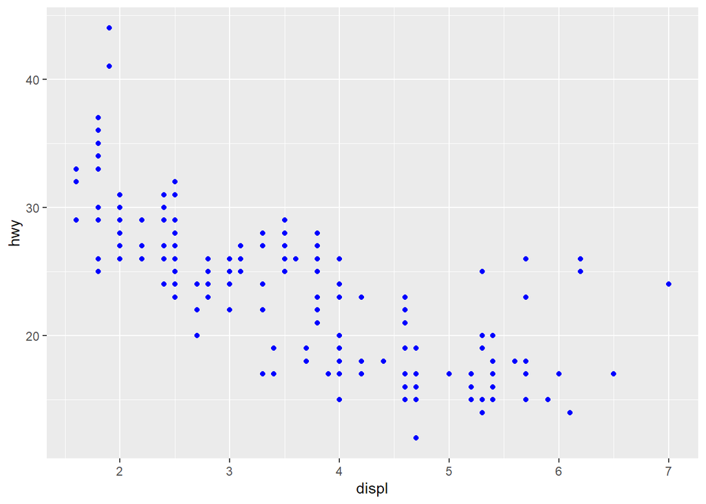

```r
library(ggplot2)
ggplot(data = mpg) +
 geom_point(mapping = aes(x = displ, y = hwy), color = "blue")
```